# Assignment 1

# Processing

## Assessing

To collate important information from the `26 samples` in the study, I run the following commands.

```r
samples <- gse@gsms
# pull the sample titles and characteristics
types <- do.call(rbind,
                 lapply(samples,,
                        FUN=function(x, ...){
                          c(x@header$title,
                            x@header$characteristics_ch1)
                        }))
```

Every sample has the characteristic `gender: female` and `tissue: Primary Breast Tumor`, so these columns are redundant for our case and can be removed.

Furthermore, cleanup can be performed on clinical subtype (condition) strings.

```r
types <- types[,c(1,2)]
colnames(types) <- c("sample", "subtype")
types[,"subtype"] <- gsub(types[,"subtype"],
                          pattern = "clinical_subtype: ",
                          replacement = "")
```

#### The control and test conditions

Breast cancers are **clinically** stratified based on:

- expression of the estrogen receptor (*ER*),
- expression of the progesterone receptor (*PR*), and
- overexpression of *HER2* (or amplification of *HER2* gene *ERBB2*)

This results in the following three **clinical subtypes** within this dataset:

- Luminal ie. *ER+*; (*ER+*, *PR+/-*)
- *HER2+*; (*HER2+*, *ER+/-*, *PR+/-*)
- Triple Negative ie. *TNBC*; (*ER-*, *PR-*, *HER2-*)

Breast cancers are also stratified on bulk transcriptomic profiling via PAM50 [3] gene signatures, describing five **molecular subtypes**: Luminal A, Luminal B, HER2-enriched, Basal-like, and Normal-like.

The ~70-80% concordance between clinical and molecular subtypes motivated this study to improve the functional understanding of these subtypes.

Conclusively, the clinical subtype conditions in this dataset are as follows:

- *HER2+* ; (*HER2+*, *ER-*, *PR+/-*)
- *HER2+/ER+* ; (*HER2+*, *ER+*, *PR+/-*)
- *ER+* ; (*HER2-*, *ER+*, *PR+/-*)
- *TNBC* ; (*HER2-*, *ER-*, *PR-*)

For my analysis, I am using the 24 samples present in the bulk RNAseq data, so I filter out the 2 which are missing.

```r
present <- colnames(raw_counts)
types <- types[which(types[,"sample"] %in% present),]
```

We now have the `24 samples` present in our bulk RNAseq raw counts.

#### How many samples in each condition?

This includes the following splits on the clinical subtypes within the bulk RNAseq dataset.

```r
her2 = length(which(types[,"subtype"] == "HER2+"))
her2er = length(which(types[,"subtype"] == "HER2+/ER+"))
tnbc = length(which(types[,"subtype"] == "TNBC"))
er = length(which(types[,"subtype"] == "ER+"))
total = sum(her2, her2er, tnbc, er)

subtype_counts = data.frame(c(her2, her2er, tnbc, er, total),
                            row.names = c("HER2+ ; (HER2+, ER-, PR+/-)",
                                          "HER2+/ER+ ; (HER2+, ER+, PR+/-)",
                                          "TNBC ; (HER2-, ER-, PR-)",
                                          "ER+ ; (HER2-, ER+, PR+/-)", "Total"))
subtype_counts$percentages = subtype_counts[,1] * 100 / total
kable(subtype_counts,
      caption="Clinical subtype condition splits",
      format="html",
      digits = 2,
      col.names = c("Count", "Percentage"))
```

Clinical subtype condition splits

|  | Count | Percentage |
| --- | --- | --- |
| HER2+ ; (HER2+, ER-, PR+/-) | 2 | 8.33 |
| HER2+/ER+ ; (HER2+, ER+, PR+/-) | 2 | 8.33 |
| TNBC ; (HER2-, ER-, PR-) | 8 | 33.33 |
| ER+ ; (HER2-, ER+, PR+/-) | 12 | 50.00 |
| Total | 24 | 100.00 |

Of the four included conditions, `ER+` ie. (*HER2-*, *ER+*) makes up `50%` of samples **alone**.

## Mapping

#### Handling Non-Unique Expression values for Specific Genes

First, I wanted to characterize the gene symbols to determine where to go with mapping. Most non-unique expression values were from gene identifiers of uncharacterized genes from [Roswell Park](https://www.roswellpark.org/) BAC clones.

```r
all_versioned <- rownames(raw_counts)
versioned <- all_versioned[grep(all_versioned, pattern = "[.].*$")]
```

Of the total versioned genes, there are `23312` genes with versions.

```r
all_unversioned <- gsub("[.]\\d+", "", all_versioned)
duplicates <- all_unversioned[duplicated(all_unversioned)]
all_unversioned <- unique(all_unversioned)
```

Removing the versions from the genes removes `9349` ~ `16.012126`% of versioned genes within our data.

However, this still leaves us with `49038` unversioned genes of the previous `58387` genes.

```r
rp_duplicates <- duplicates[grep(duplicates,
                                 pattern = "^[R][P].*[-]")]
```

There are `6393` versioned `RP` genes which are duplicates making about `68.3816451`% of all duplicates with respect to version.

The remaining duplicates can be checked against `biomaRt` [4] [5] to see if any have valid Hugo Symbols and cannot be discarded.

```r
library(biomaRt)
```

The publication uses `GRCh38`, so we can use the current *homo sapiens* ensembl.

```r
ensembl <- useMart("ensembl")
dataset <- useDataset("hsapiens_gene_ensembl", mart=ensembl)
```

The following function converts gene symbols only if they are not an existing `rds` file already, to save CPU resource. Although it appears the gene symbols are already HGNC, I am using `biomaRt` to check that they are current and updated gene symbols so the rest will be discarded.

The gene symbol annotations appeared very messy and filled with varying formats of gene symbols, so this will exclude genes that may be outdated or use improper symbols.

```r
convert_if <- function(genes) {
  conversion_filepath <- "conversion.rds"
  # if conversion file exists
  if(file.exists(conversion_filepath)) {
    # read it in
    conversion <- readRDS(conversion_filepath)
  } else { # otherwise, fetch it
    # all genes without '-'
    all_symbol <- genes[grep(genes, pattern = "^[^-]*$")]
    # all genes with '-'
    all_trans <- genes[grep(genes, pattern = "^.*[-]+.*$")]
    conversion <- getBM(attributes =
                          c("hgnc_symbol"),
                        filters =
                          c("hgnc_symbol"),
                        values = all_symbol,
                        mart = dataset)
    # and save it
    saveRDS(conversion, conversion_filepath)
  }
  return(conversion)
}
```

```r
conversion <- convert_if(all_unversioned)
```

#### Expression values that could not be mapped to current HUGO symbols

We were able to map `28712` genes of the original `49038`.

This was difficult since there are quite a large portion of genes present that are already HGNC symbols, so I had to run the unversioned ones through `biomaRt` to make sure they were current.

And, in fact, a lot of them were not current, or were different symbols. So this mapping was something of a filtering operation as well.

#### Replicates

As for the duplicated original versions in the raw counts, I decided to drop all duplicates at the moment since there are so many genes present.

```r
# add unversioned column to denote unversioned gene name
raw_counts$unversioned <- gsub("[.]\\d+", "", rownames(raw_counts))
# remove rows with duplicate unversioned names
raw_counts <- raw_counts[- which(duplicated(raw_counts$unversioned)),]
# change the rownames to be unversioned
rownames(raw_counts) <- raw_counts$unversioned
# remove unversioned column
raw_counts <- raw_counts[, !(names(raw_counts) %in% c("unversioned"))]
```

```r
mapped <- conversion$hgnc_symbol
raw_counts <- raw_counts[which(rownames(raw_counts) %in% mapped),]
```

And now, we have `28712` unversioned genes that have been successfully mapped/verified to be HGNC.

## Cleaning

#### Outliers

The associated publication [1] removed all cells that did not pass quality control already, and in their analysis they removed any tumours with < 150 cancer cells.

For the cleaning and normalizing, I make use of `edgeR` [6].

```r
library(edgeR)
```

```r
counts_matrix <- as.matrix(raw_counts)
min_num <- 12

# remove min number of samples
keep <- rowSums(edgeR::cpm(counts_matrix) > 1) > min_num
filtered_matrix <- counts_matrix[keep,]
# filter out all NA's
filtered_matrix <- na.omit(filtered_matrix)
```

To plot these in comparison with their normalized values, I make use of `RColorBrewer` [7].

```r
types_df <- as.data.frame(types)

d <- DGEList(counts = filtered_matrix, group = types_df$subtype)
d <- calcNormFactors(d, method = "TMM")
normalized_counts <- cpm(d)
```

```r
par(mfrow=c(1,2))
filt_cpm <- log2(edgeR::cpm(filtered_matrix))
filt_norm <- log2(normalized_counts)

boxplot(filt_cpm, xlab="Samples", ylab="log2(CPM)",
        las = 2, cex = 0.5, cex.lab = 0.5,
        cex.axis = 0.5, main = "Original")
```

[output not shown]

```r
abline(h = median(apply(filt_cpm, 2, median)),
       col = "red", lwd = 0.6, lty = "dashed")
```

```r
boxplot(filt_norm, xlab="Samples", ylab ="log2(CPM)",
        las = 2, cex = 0.5, cex.lab = 0.5,
        cex.axis = 0.5, main = "Normalized")
```

[output not shown]

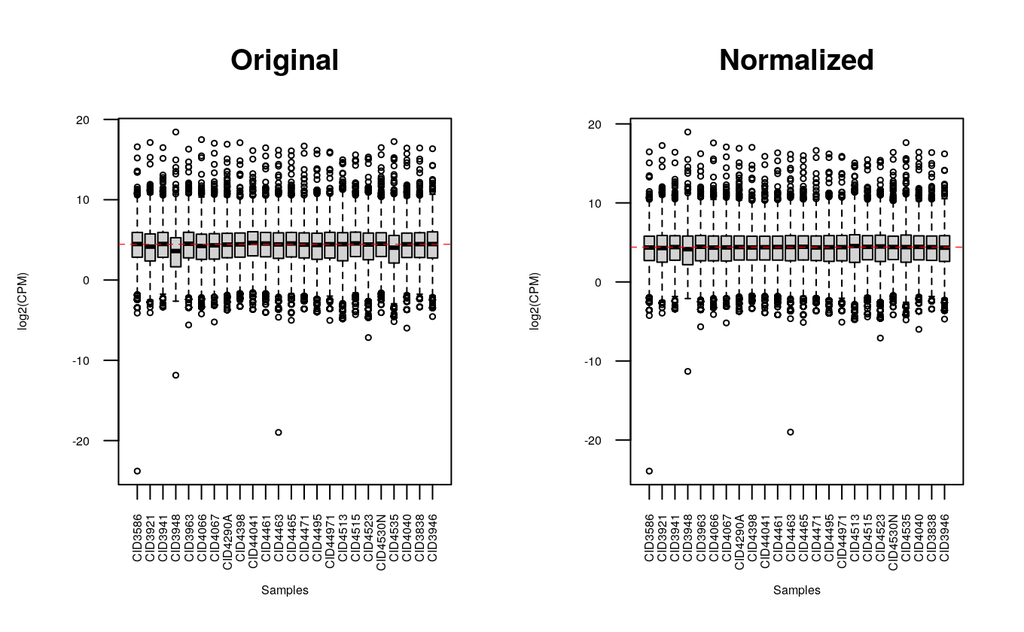

```r
abline(h = median(apply(filt_norm, 2, median)),
       col = "red", lwd = 0.6, lty = "dashed")
```

```r
density_counts <- apply(log2(edgeR::cpm(filtered_matrix)), 2, density)


xlim <- 0; ylim <- 0
for (i in 1:length(density_counts)) {
  xlim <- range(c(xlim, density_counts[[i]]$x));
  ylim <- range(c(ylim, density_counts[[i]]$y))
}
cols <- rainbow(length(density_counts))
ltys <- rep(1, length(density_counts))
xlim[1] = -10

plot(density_counts[[1]], xlim=xlim, ylim=ylim, type="n",
     ylab="Smoothing density of log2(CPM)", main="Original", cex.lab = 0.8)
for (i in 1:length(density_counts)) lines(density_counts[[i]], col=cols[i])
```

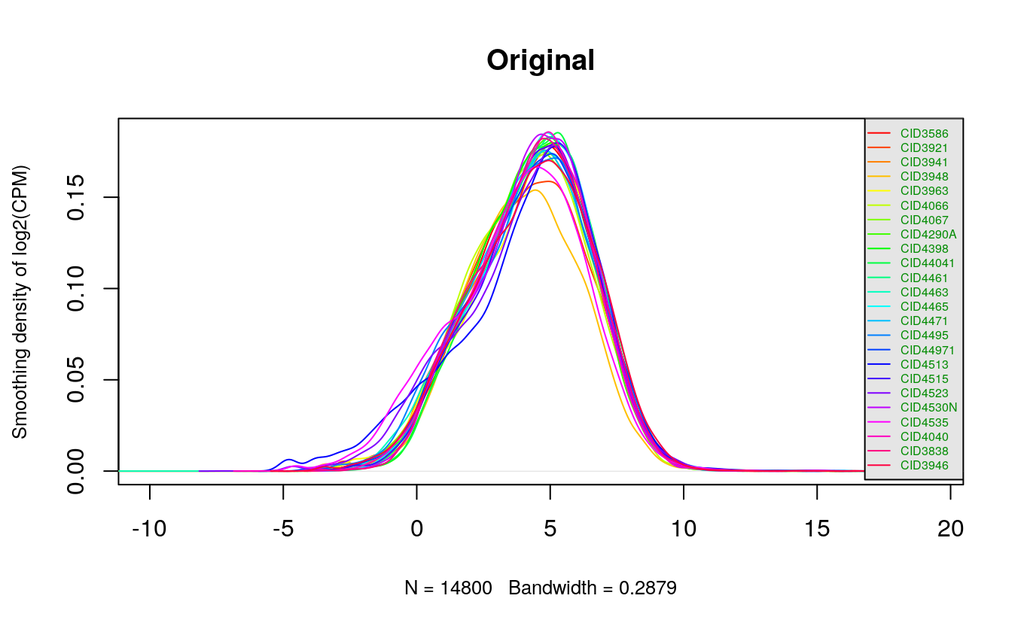

```r
legend("topright", colnames(filt_cpm),
       col=cols, lty=ltys, cex=0.5,
       border ="blue",  text.col = "green4",
       merge = TRUE, bg = "gray90")
```

```r
norm_density_counts <- apply(log2(normalized_counts), 2, density)
xlim <- 0; ylim <- 0
for (i in 1:length(norm_density_counts)) {
  xlim <- range(c(xlim, norm_density_counts[[i]]$x));
  ylim <- range(c(ylim, norm_density_counts[[i]]$y))
}
xlim[1] = -10
cols <- rainbow(length(norm_density_counts))
ltys <- rep(1, length(norm_density_counts))
plot(norm_density_counts[[1]], xlim=xlim, ylim=ylim, type="n",
     ylab="Smoothing density of log2-CPM",
     main="Figure 2: Smoothing density of filtered and normalized CPM", cex.lab = 0.8)
for (i in 1:length(norm_density_counts)) lines(norm_density_counts[[i]], col=cols[i])
```

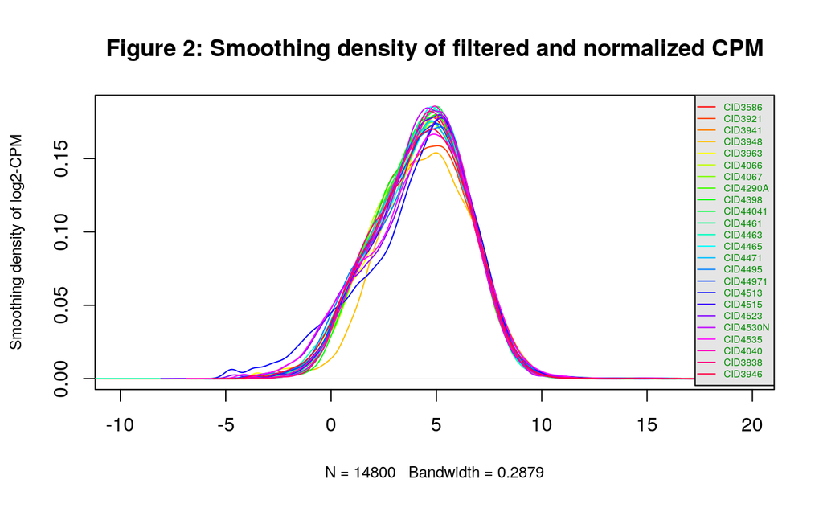

```r
legend("topright", colnames(filt_norm),
       col=cols, lty=ltys, cex=0.5,
       border ="blue",  text.col = "green4",
       merge = TRUE, bg = "gray90")
```

```r
# MDS plot

limma::plotMDS(normalized_counts, labels=NULL, pch=1,
               col = c("green", "blue", "pink", "purple")[factor(types_df$subtype)])
title("Figure 2: MDS Plot for filtered, normalized CPM by clinical subtype")
```

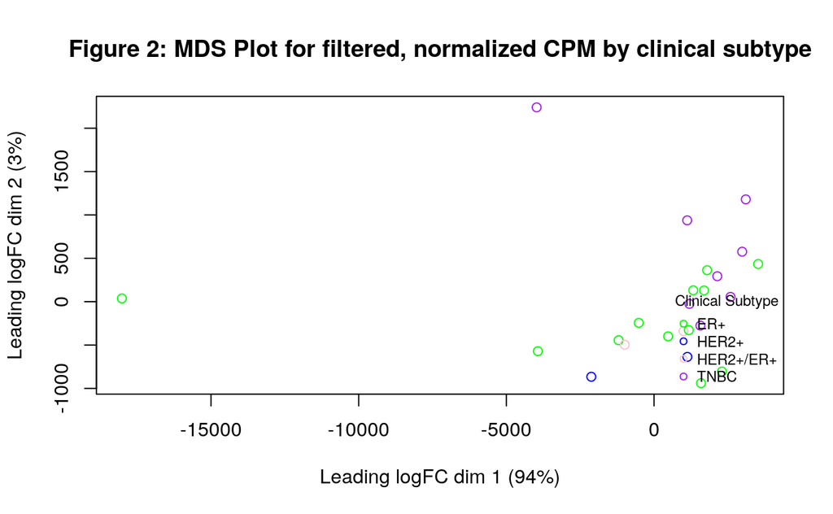

```r
legend("bottomright", legend=levels(factor(types_df$subtype)),
       pch=c(1), col=c("green", "blue", "pink", "purple"), title="Clinical Subtype",
       bty = 'n', cex = 0.75, border="blue", bg="gray90")
```

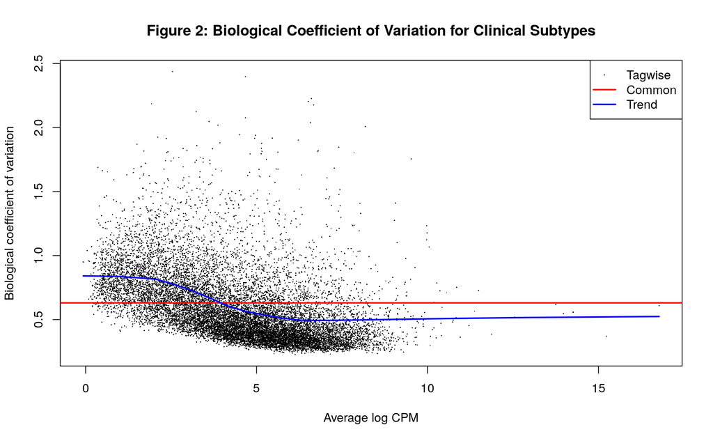

```r
model_design <- model.matrix(~types_df$subtype)
d <- estimateDisp(d, model_design)

plotBCV(d, col.tagwise="black", col.common="red",)
title("Figure 2: Biological Coefficient of Variation for Clinical Subtypes")
```

- *HER2+* ; (*HER2+*, *ER-*, *PR+/-*)
- *HER2+/ER+* ; (*HER2+*, *ER+*, *PR+/-*)
- *ER+* ; (*HER2-*, *ER+*, *PR+/-*)
- *TNBC* ; (*HER2-*, *ER-*, *PR-*)

```r
her2p <- types_df[types_df$`her2+` == TRUE,]
data_subset <- raw_counts[,her2p$sample]

data_matrix_subset <- as.matrix(data_subset)
keep <- rowSums(cpm(data_matrix_subset) > 1) > min_num
filtered_matrix_subset <- data_matrix_subset[keep,]

d_subset = DGEList(counts = data_matrix_subset,
                   group = sample_subset$subtype)
```

[output not shown]

```r
write.table(normalized_counts,
            file.path(getwd(), geo_id,
                      paste(geo_id,
                            "normalized_counts.txt",
                            sep="_")),
            quote=FALSE,sep="\t",row.name=TRUE)
```

```r
library(RColorBrewer)
```

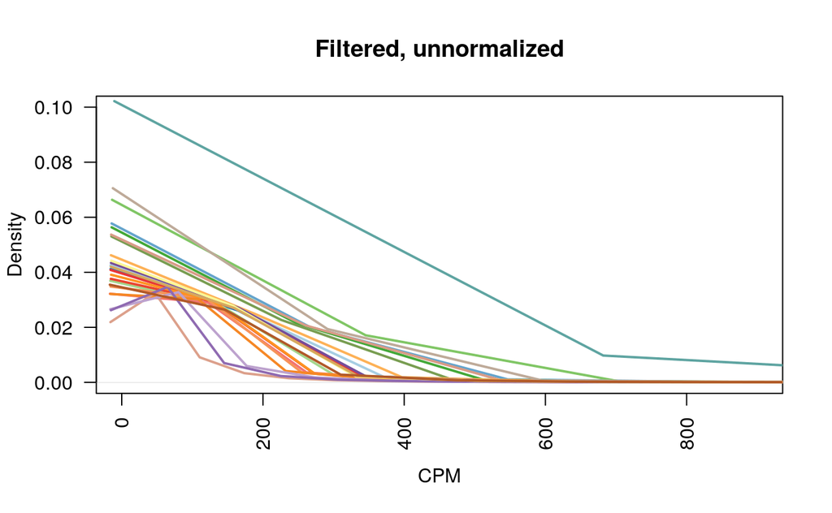

```r
plot_density <- function(matrix, title) {
  nsamples <- ncol(matrix)
  col <- colorRampPalette( brewer.pal(12,"Paired") )(nsamples)

  cpm <- edgeR::cpm(matrix)

  plot(density(cpm[,1]), col=col[1], lwd=2,
       ylim=c(0,0.1), xlim=c(0,900), las=2, main="", xlab="")
  title(main=title, xlab="CPM")
  for (i in 2:nsamples){
    den <- density(cpm[,i])
    lines(den$x, den$y, col=col[i], lwd=2)
  }
}

plot_density(filtered_matrix, "Filtered, unnormalized")
```

#### Coverage

Our final dataset contains `14800` genes which gives us a coverage of `25.3481083`% of the original gene rows present.

We could opt to be more conservative on the filtering, or mapping constraints, however this would prove to be more difficult. I want to see what I can find with this current coverage, and if it proves to be more difficult, I can come back and implement some more leniency.